# credit_card_churner_predictor

# Observations on attrition flag count considering income category.

- Most existing customers earn less than 40 k
- Least number of existing customers earn more than 120k.
- 40-60k earners are the second highest in the existing customers space.
- Most attrited customers earn less than 40 k
- Least number of attrited customers earn more than 120k.
- 40-60k earners are the second highest in the attrited customers space.

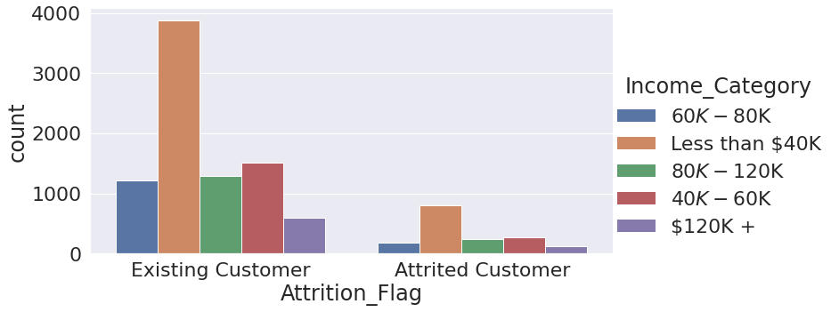

```python
sns.catplot(kind="count",
            x="Attrition_Flag",
            hue="Income_Category",
            data=data,
            aspect=2)
```

# Observations on attrition flag count considering gender category.

- More women are existing customers than men.
- More women customers have attrited than men.

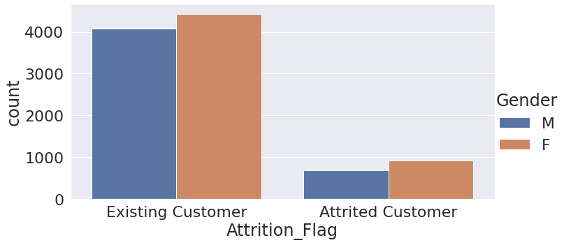

```python
sns.catplot(kind="count",
            x="Attrition_Flag",
            hue="Gender",
            data=data,
            aspect=2)
```

# Observations on attrition flag count considering education level category.

- Graduates are the highest count among existing customers
- Doctorates the least count among existing customers
- High schoolers are the second highest count among the existing customers
- More graduates are attrited compared to other categories.

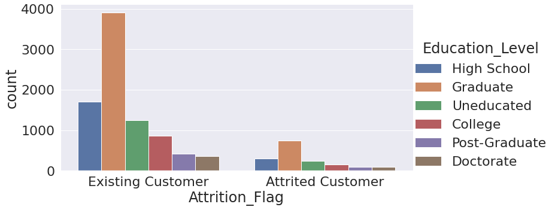

```python
sns.catplot(kind="count",
            x="Attrition_Flag",
            hue="Education_Level",
            data=data,
            aspect=2)
```

# Observations on attrition flag count considering card category.

- Most of the existing customers use the blue card
- Most of the attrited customers use the blue card
- Silver is the second highest used card among the existing customers.

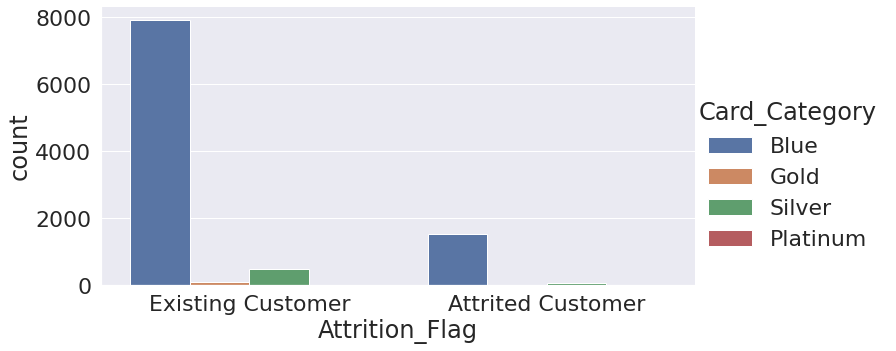

```python
sns.catplot(kind="count",
            x="Attrition_Flag",
            hue="Card_Category",
            data=data,
            aspect=2)
```

# Observations on attrition flag count considering marital status.

- Most of the existing customers are married.
- Least number of existing customers are divorced.
- Most the attrited customers are married
- Single customers are second highest attrited customers.

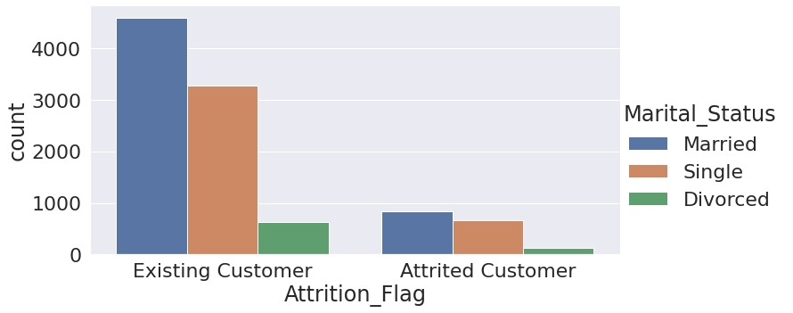

```python
sns.catplot(kind="count",
            x="Attrition_Flag",
            hue="Marital_Status",
            data=data,
            aspect=2)
```

# Observations on attrition flag count and credit limit

- Most existing customers have higher credit limit compared to the attrited customer

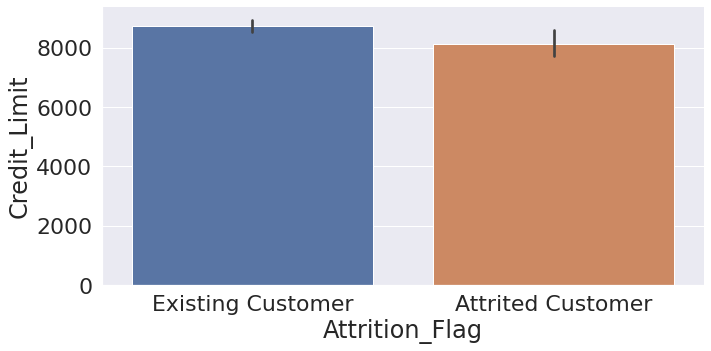

```python
sns.catplot(kind="bar",
            x="Attrition_Flag",
            y= "Credit_Limit",
            data=data,
            aspect=2)
```

# Observations on attrition flag count and total relationship count

- Most existing customers have more products than attrited customers
- This does makes sense,since if they are more involved with the bank, the less likely they are going to leave.

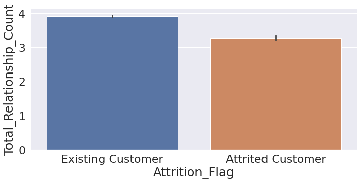

```python
sns.catplot(kind="bar",
            x="Attrition_Flag",
            y= "Total_Relationship_Count",
            data=data,
            aspect=2)
```

# Observations on attrition flag count and number of months in active

- As expected most attrited customers had more months of inactive status than current customers.

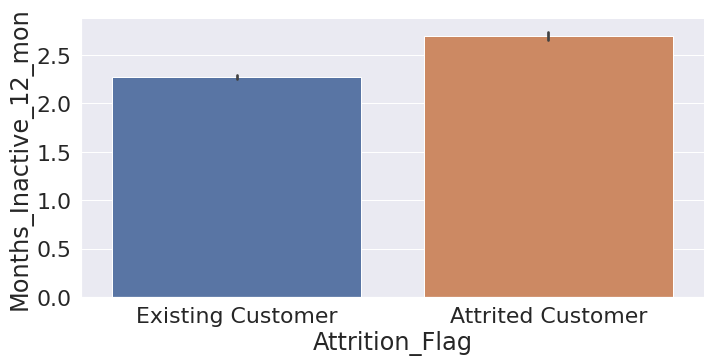

```python
sns.catplot(kind="bar",
            x="Attrition_Flag",
            y= "Months_Inactive_12_mon",
            data=data,
            aspect=2)
```

# Observations on attrition flag count and Contacts_Count_12_mon

- Attrited customers have more contact with the bank than existing customers.
- This is very intersting, seems like they have been reaching out to the bank for help (or for info). And may be because of poor response from the bank, they have decided to call it quits ?. This needs to be looked at by the customer support team.

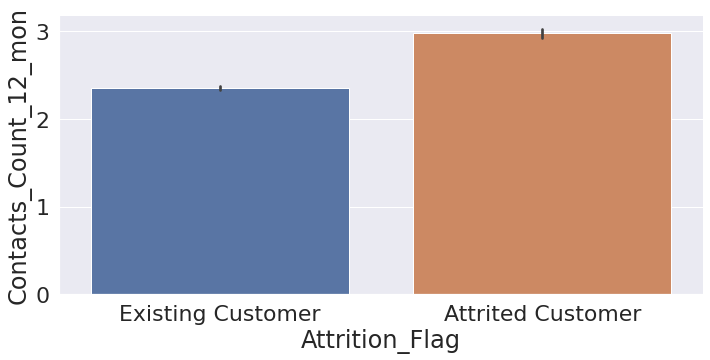

```python
sns.catplot(kind="bar",
            x="Attrition_Flag",
            y= "Contacts_Count_12_mon",
            data=data,
            aspect=2)
```

# Observations on attrition flag count and total revolving balance

- As expected, exsisting customers have more revolving balance than attrited customers

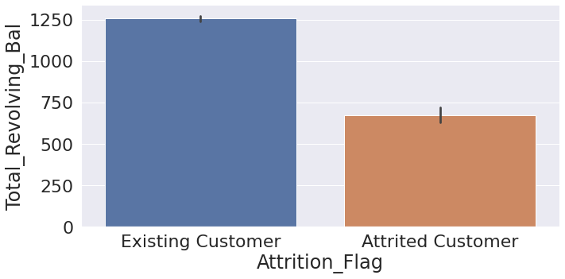

```python
sns.catplot(kind="bar",
            x="Attrition_Flag",
            y= "Total_Revolving_Bal",
            data=data,
            aspect=2)
```

# Observations on attrition flag count and total transaction amount

- As expected, total transaction amount is larger for existing customer than attrited customer

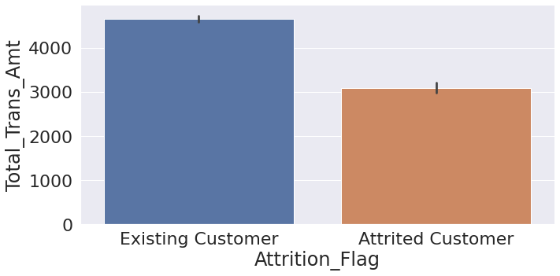

```python
sns.catplot(kind="bar",
            x="Attrition_Flag",
            y= "Total_Trans_Amt",
            data=data,
            aspect=2)
```

# Observations on attrition flag count and average utilization ratio

- As expected, existing customers have good utilization ratio compared to attrited customers.

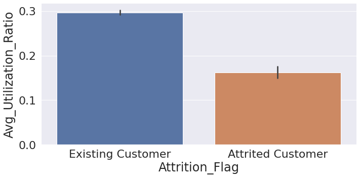

```python
sns.catplot(kind="bar",
            x="Attrition_Flag",
            y= "Avg_Utilization_Ratio",
            data=data,
            aspect=2)
```

# Data pre-processing

## Missing Value treatment

This was done before already for better EDA. Here is the link: Missing value treatment (to a previous cell)

## Data prep work - Fixing the income category field

This was done before already for better EDA. Here is the link: fixing_income_category (to a previous cell)

## Data prep work - Removing the total transaction count field below

There is very strong correlation between the transaction count and the amount (which makes sense, the more transcation we make, the more amount). Hence just removing the transaction count field.

```python
data.drop(columns="Total_Trans_Ct",inplace=True)
```

```python
data.columns
```

```
Index(['Attrition_Flag', 'Customer_Age', 'Gender', 'Dependent_count',
       'Education_Level', 'Marital_Status', 'Income_Category', 'Card_Category',
       'Months_on_book', 'Total_Relationship_Count', 'Months_Inactive_12_mon',
       'Contacts_Count_12_mon', 'Credit_Limit', 'Total_Revolving_Bal',
       'Avg_Open_To_Buy', 'Total_Amt_Chng_Q4_Q1', 'Total_Trans_Amt',
       'Total_Ct_Chng_Q4_Q1', 'Avg_Utilization_Ratio'],
      dtype='object')
```

## Data prep work - Removing the age column below

There is very strong correlation between the age and months on book (which makes sense, the more time you spend with a bank, your age also increase, as time goes by)

```python
data.drop(columns="Customer_Age",inplace=True)
```

```python
data.head()
```

|  | Attrition_Flag | Gender | Dependent_count | Education_Level | Marital_Status | Income_Category | Card_Category | Months_on_book | Total_Relationship_Count | Months_Inactive_12_mon | Contacts_Count_12_mon | Credit_Limit | Total_Revolving_Bal | Avg_Open_To_Buy | Total_Amt_Chng_Q4_Q1 | Total_Trans_Amt | Total_Ct_Chng_Q4_Q1 | Avg_Utilization_Ratio |
| --- | --- | --- | --- | --- | --- | --- | --- | --- | --- | --- | --- | --- | --- | --- | --- | --- | --- | --- |
| 0 | Existing Customer | M | 3 | High School | Married | $60K - $80K | Blue | 39 | 5 | 1 | 3 | 12691.0 | 777 | 11914.0 | 1.335 | 1144 | 1.625 | 0.061 |
| 1 | Existing Customer | F | 5 | Graduate | Single | Less than $40K | Blue | 44 | 6 | 1 | 2 | 8256.0 | 864 | 7392.0 | 1.541 | 1291 | 3.714 | 0.105 |
| 2 | Existing Customer | M | 3 | Graduate | Married | $80K - $120K | Blue | 36 | 4 | 1 | 0 | 3418.0 | 0 | 3418.0 | 2.594 | 1887 | 2.333 | 0.000 |
| 3 | Existing Customer | F | 4 | High School | Married | Less than $40K | Blue | 34 | 3 | 4 | 1 | 3313.0 | 2517 | 796.0 | 1.405 | 1171 | 2.333 | 0.760 |
| 4 | Existing Customer | M | 3 | Uneducated | Married | $60K - $80K | Blue | 21 | 5 | 1 | 0 | 4716.0 | 0 | 4716.0 | 2.175 | 816 | 2.500 | 0.000 |

# Outlier treatment

## Check presence of outlier

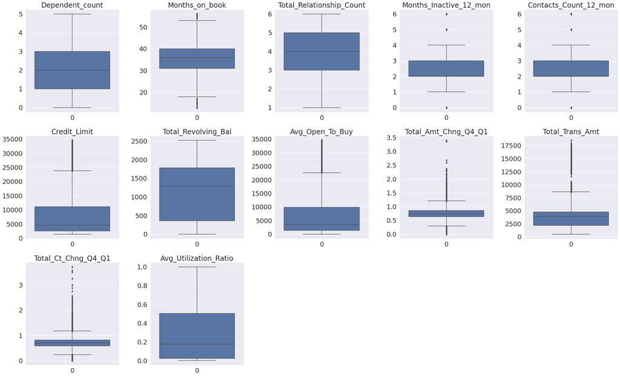

```python
numerical_col = data.select_dtypes(include=np.number).columns.tolist()
box_plot_num_columns(numerical_col)
```

# Discussion on outliers:

- Months_on_books: There are some customers, who has been with the bank for a while and this makes sense. No need to treat it as outliers.
- Months_Inactive_12_mon: there are very very few customers with very high number of inactive months and also very less (this needs to be treated as well)
- Contacts_count_12_mon: very few customers with very high 12 month count and very less 12 month count (this needs to be treated).
- Credit_Limit: Some of the old customers have higher limit and this makes sense. Not treating this as an outlier.
- Avg_open_to_buy: Almost 793 customers represent this outlier. this is a decent number of them, not treating them as outliers.
- Total_Amt_Chng_Q4_Q1: Same here, represent a decent amount of customers. not treating this as outliers.
- Total_Trans_Amt: Same here, represent a decent amount of customers. not treating this as outliers.
- Total_Ct_Chng_q4_q1: Same here, represent a decent amount of customers. not treating this as outliers.

## Treating the outliers below

```python
numerical_col = ["Months_Inactive_12_mon","Contacts_Count_12_mon"]
data = treat_all_outliers(data, numerical_col)
```

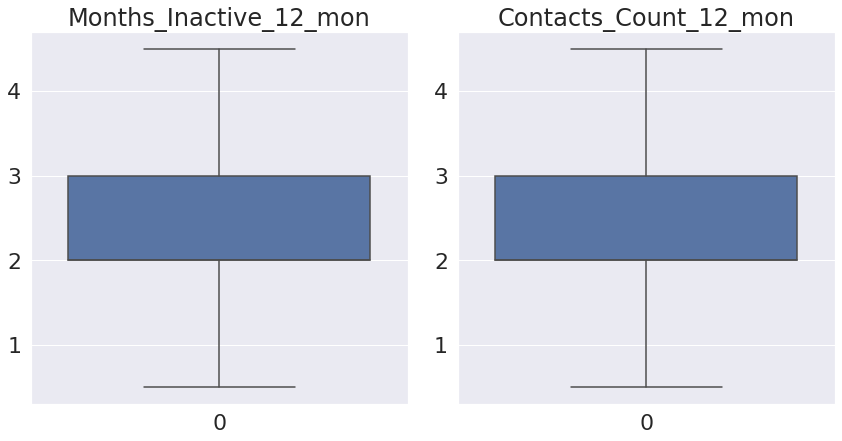

```python
# Now plot the results and see again
box_plot_num_columns(columns=numerical_col)
```

# Check for skewness in the data

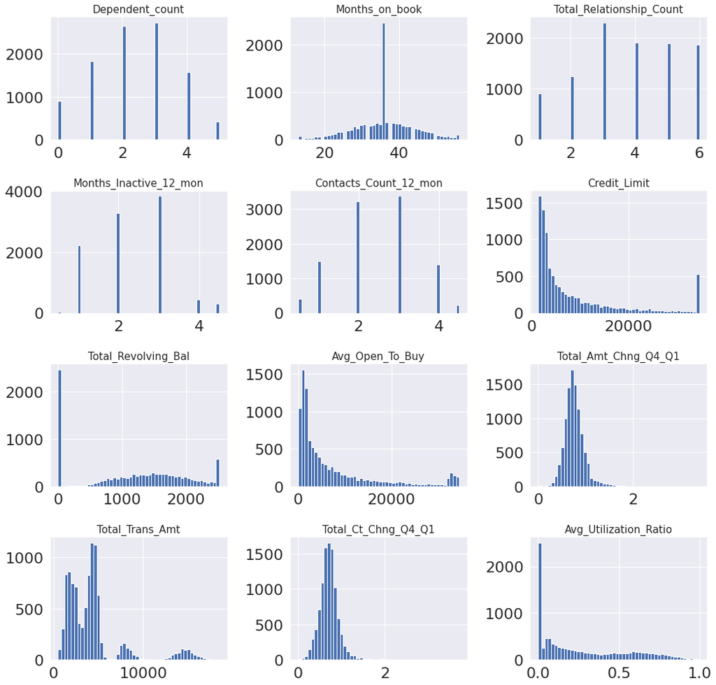

```python
# creating a list of numerical columns
num_cols = [
    num_col for num_col in data.select_dtypes(include=np.number).columns
]

plt.figure(figsize=(15, 35))

# then plot the numerical columns.
for i in range(len(num_cols)):
    plt.subplot(10, 3, i + 1)
    plt.hist(data[num_cols[i]], bins=50)
    plt.tight_layout()
    plt.title(num_cols[i], fontsize=15)

plt.show()
```

# Apply log transformation to some skewed fields:

As observed above, we will need to fix the skewness for the fields below:

- Credit_Limit
- Avg_Open_To_Buy
- Total_Revolving_Bal
- Total_Trans_Amt
- Avg_Utilization_Ratio

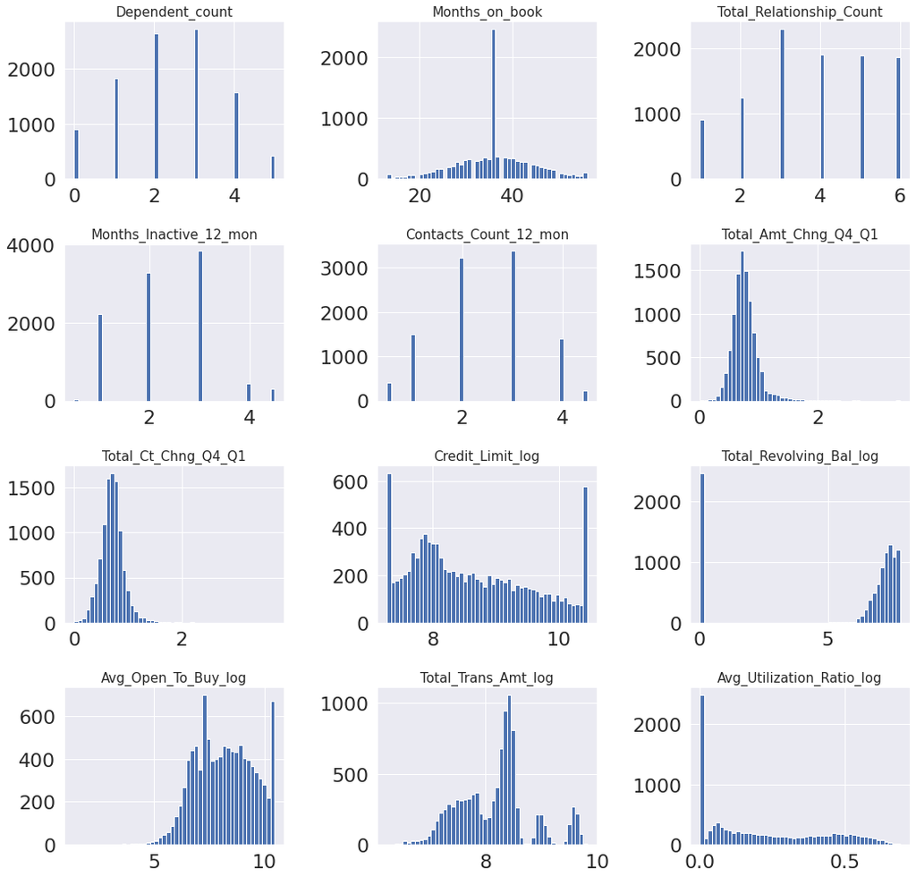

```python
data_skew_fixed = data.copy()
# these are the skewed ones, we need to log transform
num_cols = ['Credit_Limit',
            'Total_Revolving_Bal',
            'Avg_Open_To_Buy',
            'Total_Trans_Amt',
            'Avg_Utilization_Ratio']


# apply the log transform
for col in num_cols:
    data_skew_fixed[col + "_log"] = np.log(data_skew_fixed[col] + 1)


# drop the original numerical columns and use the log ones.
data_skew_fixed.drop(num_cols, axis=1, inplace=True)

# Creating a list of numerical columns with log transform applied.
num_cols = [
    num_col for num_col in data_skew_fixed.select_dtypes(include=np.number).columns
]

plt.figure(figsize=(15, 35))

for i in range(len(num_cols)):
    plt.subplot(10, 3, i + 1)
    plt.hist(data_skew_fixed[num_cols[i]], bins=50)
    plt.tight_layout()
    plt.title(num_cols[i], fontsize=15)

plt.show()
```

# Data prep work- Encoding the target variable

```python
data_skew_fixed["Attrition_Flag"].replace("Existing Customer", 0, inplace=True)
data_skew_fixed["Attrition_Flag"].replace("Attrited Customer", 1, inplace=True)
```

```python
data_skew_fixed
```

|  | Attrition_Flag | Gender | Dependent_count | Education_Level | Marital_Status | Income_Category | Card_Category | Months_on_book | Total_Relationship_Count | Months_Inactive_12_mon | Contacts_Count_12_mon | Total_Amt_Chng_Q4_Q1 | Total_Ct_Chng_Q4_Q1 | Credit_Limit_log | Total_Revolving_Bal_log | Avg_Open_To_Buy_log | Total_Trans_Amt_log | Avg_Utilization_Ratio_log |
| --- | --- | --- | --- | --- | --- | --- | --- | --- | --- | --- | --- | --- | --- | --- | --- | --- | --- | --- |
| 0 | 0 | M | 3 | High School | Married | $60K - $80K | Blue | 39 | 5 | 1.0 | 3.0 | 1.335 | 1.625 | 9.448727 | 6.656727 | 9.385553 | 7.043160 | 0.059212 |
| 1 | 0 | F | 5 | Graduate | Single | Less than $40K | Blue | 44 | 6 | 1.0 | 2.0 | 1.541 | 3.714 | 9.018817 | 6.762730 | 8.908289 | 7.163947 | 0.099845 |
| 2 | 0 | M | 3 | Graduate | Married | $80K - $120K | Blue | 36 | 4 | 1.0 | 0.5 | 2.594 | 2.333 | 8.137103 | 0.000000 | 8.137103 | 7.543273 | 0.000000 |
| 3 | 0 | F | 4 | High School | Married | Less than $40K | Blue | 34 | 3 | 4.0 | 1.0 | 1.405 | 2.333 | 8.105911 | 7.831220 | 6.680855 | 7.066467 | 0.565314 |
| 4 | 0 | M | 3 | Uneducated | Married | $60K - $80K | Blue | 21 | 5 | 1.0 | 0.5 | 2.175 | 2.500 | 8.458928 | 0.000000 | 8.458928 | 6.705639 | 0.000000 |
| ... | ... | ... | ... | ... | ... | ... | ... | ... | ... | ... | ... | ... | ... | ... | ... | ... | ... | ... |
| 10122 | 0 | M | 2 | Graduate | Single | $40K - $60K | Blue | 40 | 3 | 2.0 | 3.0 | 0.703 | 0.857 | 8.295049 | 7.524021 | 7.674617 | 9.647110 | 0.379805 |
| 10123 | 1 | M | 2 | Graduate | Divorced | $40K - $60K | Blue | 25 | 4 | 2.0 | 3.0 | 0.804 | 0.683 | 8.361241 | 7.690286 | 7.645876 | 9.078522 | 0.412772 |
| 10124 | 1 | F | 1 | High School | Married | Less than $40K | Blue | 36 | 5 | 3.0 | 4.0 | 0.819 | 0.818 | 8.596004 | 0.000000 | 8.596004 | 9.239122 | 0.000000 |
| 10125 | 1 | M | 2 | Graduate | Married | $40K - $60K | Blue | 36 | 4 | 3.0 | 3.0 | 0.535 | 0.722 | 8.572060 | 0.000000 | 8.572060 | 9.035511 | 0.000000 |
| 10126 | 1 | F | 2 | Graduate | Married | Less than $40K | Silver | 25 | 6 | 2.0 | 4.0 | 0.703 | 0.649 | 9.248503 | 7.581720 | 9.039315 | 9.239414 | 0.173113 |

10127 rows × 18 columns

# Data prep work- hot encoding

```python
replaceStruct = {"Education_Level":{'Uneducated':1,
                                    'High School':2,
                                    'College':3,
                                    'Graduate':4,
                                    'Post-Graduate':5,
                                    'Doctorate':6
                                   },
                 "Income_Category":{"Less than $40K":1,
                                    "$40K - $60K":2,
                                    "$60K - $80K":3,
                                    "$80K - $120K":4,
                                    "$120K +":5
                                   },
                 "Card_Category":{"Blue":1,
                                  "Silver":2,
                                  "Gold":3,
                                  "Platinum":4
                                 },
                }
oneHotCols=['Gender',
            'Marital_Status',
            ]
```

```python
data_skew_fixed=data_skew_fixed.replace(replaceStruct)
data_skew_fixed=pd.get_dummies(data_skew_fixed, columns=oneHotCols)
data_skew_fixed.head(10)
```

|  | Attrition_Flag | Dependent_count | Education_Level | Income_Category | Card_Category | Months_on_book | Total_Relationship_Count | Months_Inactive_12_mon | Contacts_Count_12_mon | Total_Amt_Chng_Q4_Q1 | ... | Credit_Limit_log | Total_Revolving_Bal_log | Avg_Open_To_Buy_log | Total_Trans_Amt_log | Avg_Utilization_Ratio_log | Gender_F | Gender_M | Marital_Status_Divorced | Marital_Status_Married | Marital_Status_Single |
| --- | --- | --- | --- | --- | --- | --- | --- | --- | --- | --- | --- | --- | --- | --- | --- | --- | --- | --- | --- | --- | --- |
| 0 | 0 | 3 | 2 | 3 | 1 | 39 | 5 | 1.0 | 3.0 | 1.335 | ... | 9.448727 | 6.656727 | 9.385553 | 7.043160 | 0.059212 | 0 | 1 | 0 | 1 | 0 |
| 1 | 0 | 5 | 4 | 1 | 1 | 44 | 6 | 1.0 | 2.0 | 1.541 | ... | 9.018817 | 6.762730 | 8.908289 | 7.163947 | 0.099845 | 1 | 0 | 0 | 0 | 1 |
| 2 | 0 | 3 | 4 | 4 | 1 | 36 | 4 | 1.0 | 0.5 | 2.594 | ... | 8.137103 | 0.000000 | 8.137103 | 7.543273 | 0.000000 | 0 | 1 | 0 | 1 | 0 |
| 3 | 0 | 4 | 2 | 1 | 1 | 34 | 3 | 4.0 | 1.0 | 1.405 | ... | 8.105911 | 7.831220 | 6.680855 | 7.066467 | 0.565314 | 1 | 0 | 0 | 1 | 0 |
| 4 | 0 | 3 | 1 | 3 | 1 | 21 | 5 | 1.0 | 0.5 | 2.175 | ... | 8.458928 | 0.000000 | 8.458928 | 6.705639 | 0.000000 | 0 | 1 | 0 | 1 | 0 |
| 5 | 0 | 2 | 4 | 2 | 1 | 36 | 3 | 1.0 | 2.0 | 1.376 | ... | 8.296796 | 7.129298 | 7.924434 | 6.993015 | 0.270790 | 0 | 1 | 0 | 1 | 0 |
| 6 | 0 | 4 | 4 | 5 | 3 | 46 | 6 | 1.0 | 3.0 | 1.975 | ... | 10.449207 | 7.725330 | 10.381366 | 7.193686 | 0.063913 | 0 | 1 | 0 | 1 | 0 |
| 7 | 0 | 0 | 2 | 3 | 2 | 27 | 2 | 2.0 | 2.0 | 2.204 | ... | 10.277875 | 7.242082 | 10.228682 | 7.338888 | 0.046884 | 0 | 1 | 0 | 1 | 0 |
| 8 | 0 | 3 | 1 | 3 | 1 | 36 | 5 | 2.0 | 0.5 | 3.355 | ... | 10.014716 | 7.831220 | 9.895254 | 7.208600 | 0.107059 | 0 | 1 | 0 | 0 | 1 |
| 9 | 0 | 2 | 4 | 4 | 1 | 36 | 6 | 3.0 | 3.0 | 1.524 | ... | 9.363662 | 7.425358 | 9.208338 | 7.273786 | 0.134531 | 0 | 1 | 0 | 0 | 1 |

10 rows × 21 columns

# Data Preparation for Modeling

```python
X = data_skew_fixed.drop(["Attrition_Flag"], axis=1)
y = data_skew_fixed["Attrition_Flag"]
```

```python
X_temp, X_test, y_temp, y_test = train_test_split(
    X, y, test_size=0.2, random_state=1, stratify=y
)

X_train, X_val, y_train, y_val = train_test_split(
    X_temp, y_temp, test_size=0.25, random_state=1, stratify=y_temp
)
```

# Meta of training, validation and test

```python
print("Number of rows in train data =", X_train.shape[0])
print("Number of rows in validation data =", X_val.shape[0])
print("Number of rows in test data =", X_test.shape[0])
```

```
Number of rows in train data = 6075
Number of rows in validation data = 2026
Number of rows in test data = 2026
```

# which metric is right for model performance evaluation ?

Before we arrive on our metric, lets chart the main info down:

- True Positive: Person who is predicted going to churn has churned.
- True Negative: Person who is predicted not going to churn did not churn.
- False Positive: Person who is predicted to churn has not churned.
- False Negative: Person who is predicted as not churned, has churned.

So looking at **false negative**, that kind of incident will be of more harm to the company (since we are loosing a customer). Hence **Recall** should be our metric here.

# Model building - Logisitc Regression

```python
lr = LogisticRegression(random_state=1)
lr.fit(X_train, y_train)
```

```
LogisticRegression(random_state=1)
```

# Model building - Logisitc Regression - performance on training data

```python
print("Logisitc Regression on training data")
print_model_performance_for_classification(model=lr,
                                           features=X_train,
                                           target=y_train)
```

```
Logisitc Regression on training data
Accuracy:0.8862551440329218
Recall:0.42110655737704916
Precision: 0.7653631284916201
F1 score: 0.543291473892928
```

# Model building - Logisitc Regression - performance on validation data

```python
print("Logisitc Regression on validation data")
print_model_performance_for_classification(model=lr,
                                           features=X_val,
                                           target=y_val)
```

```
Logisitc Regression on validation data
Accuracy:0.8889437314906219
Recall:0.48466257668711654
Precision: 0.7348837209302326
F1 score: 0.5841035120147874
```

# Model building - Decision Tree

```python
dt_estimator=DecisionTreeClassifier(random_state=1)
dt_estimator.fit(X_train,y_train)
```

```
DecisionTreeClassifier(random_state=1)
```

# Model building - Decision Tree - performance on training

```python
print("Decision tree on training data")
print_model_performance_for_classification(model=dt_estimator,
                                           features=X_train,
                                           target=y_train)
```

```
Decision tree on training data
Accuracy:1.0
Recall:1.0
Precision: 1.0
F1 score: 1.0
```

# Model building - Decision Tree - performance on validation data

```python
print("Decision tree on validation data")
print_model_performance_for_classification(model=dt_estimator,
                                           features=X_val,
                                           target=y_val)
```

```
Decision tree on validation data
Accuracy:0.9165844027640672
Recall:0.754601226993865
Precision: 0.7343283582089553
F1 score: 0.7443267776096824
```

# Model building - Bagging

```python
bagging_estimator=BaggingClassifier(random_state=1)
bagging_estimator.fit(X_train,y_train)
```

```
BaggingClassifier(random_state=1)
```

# Model building - Bagging - performance on training

```python
print("Bagging on training data")
print_model_performance_for_classification(model=bagging_estimator,
                                           features=X_train,
                                           target=y_train)
```

```
Bagging on training data
Accuracy:0.9950617283950617
Recall:0.9723360655737705
Precision: 0.9968487394957983
F1 score: 0.9844398340248962
```

# Model building - Bagging - performance on validation

```python
print("Bagging on validation data")
print_model_performance_for_classification(model=bagging_estimator,
                                           features=X_val,
                                           target=y_val)
```

```
Bagging on validation data
Accuracy:0.947680157946693
Recall:0.7975460122699386
Precision: 0.8666666666666667
F1 score: 0.8306709265175719
```

# Model building and performance - Adaboost classifier

```python
abc = AdaBoostClassifier(random_state=1)
abc.fit(X_train,y_train)
print("Adaboost classifier on the training data")
print_model_performance_for_classification(model=abc,
                                           features=X_train,
                                           target=y_train)

print("\nAdaboost classifier on the validation data")
print_model_performance_for_classification(model=abc,
                                           features=X_val,
                                           target=y_val)
```

```
Adaboost classifier on the training data
Accuracy:0.937283950617284
Recall:0.7479508196721312
Precision: 0.8439306358381503
F1 score: 0.793047256925584

Adaboost classifier on the validation data
Accuracy:0.937314906219151
Recall:0.754601226993865
Precision: 0.8395904436860068
F1 score: 0.7948303715670436
```

# Model building and performance - Gradient boost classifier

```python
gbc = GradientBoostingClassifier(random_state=1)
gbc.fit(X_train,y_train)
print("Gradientboost classifier on the training data")
print_model_performance_for_classification(model=gbc,
                                           features=X_train,
                                           target=y_train)

print("\nGradientboost classifier on the validation data")
print_model_performance_for_classification(model=gbc,
                                           features=X_val,
                                           target=y_val)
```

```
Gradientboost classifier on the training data
Accuracy:0.9613168724279836
Recall:0.8227459016393442
Precision: 0.9283236994219654
F1 score: 0.8723519826181423

Gradientboost classifier on the validation data
Accuracy:0.9605133267522211
Recall:0.8374233128834356
Precision: 0.91
F1 score: 0.8722044728434506
```

# Model building and performance - XGB boost classifier

```python
xgb = XGBClassifier(random_state=1,eval_metric='logloss',use_label_encoder=False)
xgb.fit(X_train,y_train)

print("xgb classifier on the training data")
print_model_performance_for_classification(model=xgb,
                                           features=X_train,
                                           target=y_train)

print("\nxgb classifier on the validation data")
print_model_performance_for_classification(model=xgb,
                                           features=X_val,
                                           target=y_val)
```

```
xgb classifier on the training data
Accuracy:1.0
Recall:1.0
Precision: 1.0
F1 score: 1.0

xgb classifier on the validation data
Accuracy:0.9634748272458046
Recall:0.8680981595092024
Precision: 0.9012738853503185
F1 score: 0.884375
```

# Oversampling train data using SMOTE

```python
X_train_over, y_train_over = over_sample(x_train=X_train,
                                         y_train=y_train)
```

```
Before Oversampling, counts of label 'Yes': 976
Before Oversampling, counts of label 'No': 5099

After Oversampling, counts of label 'Yes': 5099
After Oversampling, counts of label 'No': 5099

After Oversampling, the shape of train_X: (10198, 20)
After Oversampling, the shape of train_y: (10198,)
```

# Logisitic regression Model building on over sampled training data and performance evaluation

```python
lr_over = LogisticRegression(random_state=1)
lr_over.fit(X_train_over, y_train_over)

print("Logisitc Regression on over sampled training data")
print_model_performance_for_classification(model=lr_over,
                                           features=X_train_over,
                                           target=y_train_over)

print("\nLogisitc Regression on validation data")
print_model_performance_for_classification(model=lr_over,
                                           features=X_val,
                                           target=y_val)
```

```
Logisitc Regression on over sampled training data
Accuracy:0.8358501666993529
Recall:0.8089821533634046
Precision: 0.8549222797927462
F1 score: 0.8313180169286578

Logisitc Regression on validation data
Accuracy:0.8208292201382034
Recall:0.7024539877300614
Precision: 0.4626262626262626
F1 score: 0.5578562728380024
```

# Decision tree model building on over sampled training data and performance evaluation

```python
dt_estimator_over=DecisionTreeClassifier(random_state=1)
dt_estimator_over.fit(X_train_over, y_train_over)

print("Decision tree classifier on over sampled training data")
print_model_performance_for_classification(model=dt_estimator_over,
                                           features=X_train_over,
                                           target=y_train_over)

print("\nDecision tree classifier on validation data")
print_model_performance_for_classification(model=dt_estimator_over,
                                           features=X_val,
                                           target=y_val)
```

```
Decision tree classifier on over sampled training data
Accuracy:1.0
Recall:1.0
Precision: 1.0
F1 score: 1.0

Decision tree classifier on validation data
Accuracy:0.8820335636722606
Recall:0.7914110429447853
Precision: 0.6013986013986014
F1 score: 0.6834437086092715
```

# Bagging estimator model building on over sampled training data and performance evaluation

```python
bagging_estimator_over=BaggingClassifier(random_state=1)
bagging_estimator_over.fit(X_train_over, y_train_over)

print("Over sampled bagging on training data")
print_model_performance_for_classification(model=bagging_estimator_over,
                                           features=X_train_over,
                                           target=y_train_over)

print("\nOver sampled bagging on validation data")
print_model_performance_for_classification(model=bagging_estimator_over,
                                           features=X_val,
                                           target=y_val)
```

```
Over sampled bagging on training data
Accuracy:0.9972543636007061
Recall:0.9966660129437145
Precision: 0.9978401727861771
F1 score: 0.9972527472527473

Over sampled bagging on validation data
Accuracy:0.9259624876604146
Recall:0.8282208588957055
Precision: 0.7417582417582418
F1 score: 0.7826086956521738
```

# Adaboost classifier model building on over sampled training data and performance evaluation.

```python
abc_over = AdaBoostClassifier(random_state=1)
abc_over.fit(X_train_over,y_train_over)

print("Over sampled AdaBoostClassifier on training data")
print_model_performance_for_classification(model=abc_over,
                                           features=X_train_over,
                                           target=y_train_over)

print("\nOver sampled AdaBoostClassifier on validation data")
print_model_performance_for_classification(model=abc_over,
                                           features=X_val,
                                           target=y_val)
```

```
Over sampled AdaBoostClassifier on training data
Accuracy:0.9327319082172975
Recall:0.9317513237889782
Precision: 0.9335822361957162
F1 score: 0.9326658814291323

Over sampled AdaBoostClassifier on validation data
Accuracy:0.9146100691016782
Recall:0.8466257668711656
Precision: 0.6917293233082706
F1 score: 0.7613793103448275
```

# Gradient Boost classifier model building on over sampled training data and performance evaluation.

```python
gbc_over = GradientBoostingClassifier(random_state=1)
gbc_over.fit(X_train_over,y_train_over)
print("Over sampled Gradientboost classifier on the training data")
print_model_performance_for_classification(model=gbc_over,
                                           features=X_train_over,
                                           target=y_train_over)

print("\n Over sampled Gradientboost classifier on the validation data")
print_model_performance_for_classification(model=gbc_over,
                                           features=X_val,
                                           target=y_val)
```

```
Over sampled Gradientboost classifier on the training data
Accuracy:0.9618552657383801
Recall:0.9564620513826241
Precision: 0.9668913560666138
F1 score: 0.9616484274869367

 Over sampled Gradientboost classifier on the validation data
Accuracy:0.9481737413622903
Recall:0.8803680981595092
Precision: 0.8130311614730878
F1 score: 0.845360824742268
```

# XGBoost classifier model building on over sampled training data and performance evaluation.

```python
xgb_over = XGBClassifier(random_state=1,eval_metric='logloss',use_label_encoder=False)
xgb_over.fit(X_train_over,y_train_over)

print("Over sampled xgb classifier on the training data")
print_model_performance_for_classification(model=xgb_over,
                                           features=X_train_over,
                                           target=y_train_over)

print("\n Over sampled xgb classifier on the validation data")
print_model_performance_for_classification(model=xgb_over,
                                           features=X_val,
                                           target=y_val)
```

```
Over sampled xgb classifier on the training data
Accuracy:0.9998038831143361
Recall:0.9998038831143361
Precision: 0.9998038831143361
F1 score: 0.9998038831143361

 Over sampled xgb classifier on the validation data
Accuracy:0.9585389930898321
Recall:0.8926380368098159
Precision: 0.8558823529411764
F1 score: 0.8738738738738737
```

# Undersampling train data using Random Under Sampler

```python
X_train_un, y_train_un = under_sample(x_train=X_train,
                                      y_train=y_train)
```

```
Before Undersampling, counts of label 'Yes': 976
Before Undersampling, counts of label 'No': 5099

After Undersampling, counts of label 'Yes': 976
After Undersampling, counts of label 'No': 976

After Undersampling, the shape of train_X: (1952, 20)
After Undersampling, the shape of train_y: (1952,)
```

# Logisitic regression Model building on under sampled training data and performance evaluation

```python
lr_un = LogisticRegression(random_state=1)
lr_un.fit(X_train_un, y_train_un)

print("Logisitc Regression on under sampled training data")
print_model_performance_for_classification(model=lr_un,
                                           features=X_train_un,
                                           target=y_train_un)

print("\nLogisitc Regression on validation data")
print_model_performance_for_classification(model=lr_un,
                                           features=X_val,
                                           target=y_val)
```

```
Logisitc Regression on under sampled training data
Accuracy:0.7827868852459017
Recall:0.764344262295082
Precision: 0.7936170212765957
F1 score: 0.778705636743215

Logisitc Regression on validation data
Accuracy:0.7808489634748272
Recall:0.8098159509202454
Precision: 0.4086687306501548
F1 score: 0.5432098765432098
```

# DecisionTreeClassifier model building on under sampled training data and performance evaluation

```python
dt_estimator_un=DecisionTreeClassifier(random_state=1)
dt_estimator_un.fit(X_train_un, y_train_un)

print("Decision tree classifier on under sampled training data")
print_model_performance_for_classification(model=dt_estimator_un,
                                           features=X_train_un,
                                           target=y_train_un)

print("\nDecision tree classifier on validation data")
print_model_performance_for_classification(model=dt_estimator_un,
                                           features=X_val,
                                           target=y_val)
```

```
Decision tree classifier on under sampled training data
Accuracy:1.0
Recall:1.0
Precision: 1.0
F1 score: 1.0

Decision tree classifier on validation data
Accuracy:0.8687068114511353
Recall:0.8895705521472392
Precision: 0.5576923076923077
F1 score: 0.6855791962174941
```

# BaggingClassifier model building on under sampled training data and performance evaluation

```python
bagging_estimator_un=BaggingClassifier(random_state=1)
bagging_estimator_un.fit(X_train_un, y_train_un)

print("Under sampled bagging on training data")
print_model_performance_for_classification(model=bagging_estimator_un,
                                           features=X_train_un,
                                           target=y_train_un)

print("\nUnder sampled bagging on validation data")
print_model_performance_for_classification(model=bagging_estimator_un,
                                           features=X_val,
                                           target=y_val)
```

```
Under sampled bagging on training data
Accuracy:0.9974385245901639
Recall:0.9948770491803278
Precision: 1.0
F1 score: 0.997431946584489

Under sampled bagging on validation data
Accuracy:0.9067127344521224
Recall:0.9263803680981595
Precision: 0.6466809421841542
F1 score: 0.7616645649432534
```

# AdaBoostClassifier model building on under sampled training data and performance evaluation

```python
abc_un = AdaBoostClassifier(random_state=1)
abc_un.fit(X_train_un,y_train_un)

print("Under sampled AdaBoostClassifier on training data")
print_model_performance_for_classification(model=abc_un,
                                           features=X_train_un,
                                           target=y_train_un)

print("\nUnder sampled AdaBoostClassifier on validation data")
print_model_performance_for_classification(model=abc_un,
                                           features=X_val,
                                           target=y_val)
```

```
Under sampled AdaBoostClassifier on training data
Accuracy:0.9221311475409836
Recall:0.9293032786885246
Precision: 0.9161616161616162
F1 score: 0.9226856561546286

Under sampled AdaBoostClassifier on validation data
Accuracy:0.8909180651530109
Recall:0.9202453987730062
Precision: 0.6060606060606061
F1 score: 0.7308160779537151
```

# GradientBoostingClassifier model building on under sampled training data and performance evaluation

```python
gbc_un = GradientBoostingClassifier(random_state=1)
gbc_un.fit(X_train_un,y_train_un)
print("Under sampled Gradientboost classifier on the training data")
print_model_performance_for_classification(model=gbc_un,
                                           features=X_train_un,
                                           target=y_train_un)

print("\n Under sampled Gradientboost classifier on the validation data")
print_model_performance_for_classification(model=gbc_un,
                                           features=X_val,
                                           target=y_val)
```

```
Under sampled Gradientboost classifier on the training data
Accuracy:0.9564549180327869
Recall:0.9610655737704918
Precision: 0.9522842639593908
F1 score: 0.9566547679755227

 Under sampled Gradientboost classifier on the validation data
Accuracy:0.9180651530108588
Recall:0.9447852760736196
Precision: 0.6754385964912281
F1 score: 0.7877237851662404
```

# XGBClassifier model building on under sampled training data and performance evaluation

```python
xgb_un = XGBClassifier(random_state=1,eval_metric='logloss',use_label_encoder=False)
xgb_un.fit(X_train_un,y_train_un)

print("Under sampled xgb classifier on the training data")
print_model_performance_for_classification(model=xgb_un,
                                           features=X_train_un,
                                           target=y_train_un)

print("\n Under sampled xgb classifier on the validation data")
print_model_performance_for_classification(model=xgb_un,
                                           features=X_val,
                                           target=y_val)
```

```
Under sampled xgb classifier on the training data
Accuracy:1.0
Recall:1.0
Precision: 1.0
F1 score: 1.0

 Under sampled xgb classifier on the validation data
Accuracy:0.9131293188548865
Recall:0.9386503067484663
Precision: 0.6623376623376623
F1 score: 0.7766497461928934
```

# Choose to tune 3 models

- XGB: XGBClassifier
- GBC: GBC
- XGB_OVER: Over sampled XGBClassifier

These three have good **recall** scores and also good **F1 score** on the validation data. We will try to tune these models to gain better performance on **recall** side of things.

# Tunning the XGBoost classifier on the training data and testing performance on test data

```python
parameters = {
    "n_estimators": np.arange(10,90,20),
    "scale_pos_weight":[0,1,2,5],
}
xgb_tuned =tune_model(model=xgb,
                      parameters=parameters,
                      X_train=X_train,
                      y_train=y_train)



print("\nTuned xgboost classifier on the testing data")
print_model_performance_for_classification(model=xgb_tuned,
                                           features=X_test,
                                           target=y_test)
```

```
Tuned xgboost classifier on the testing data
Accuracy:0.9383020730503455
Recall:0.9323076923076923
Precision: 0.7463054187192119
F1 score: 0.8290013679890561
```

# Tunning the Gradientboost classifier on the training data and testing performance on the test data

```python
parameters = {
    "n_estimators": [100,150],
    "subsample":[0.3,0.9,1],

}
gbc_tuned =tune_model(model=gbc,
                      parameters=parameters,
                      X_train=X_train,
                      y_train=y_train)



print("\nTuned gradientboost classifier on the testing data")
print_model_performance_for_classification(model=gbc_tuned,
                                           features=X_test,
                                           target=y_test)
```

```
Tuned gradientboost classifier on the testing data
Accuracy:0.9590325765054294
Recall:0.8184615384615385
Precision: 0.9172413793103448
F1 score: 0.8650406504065041
```

# Tunning the over sampled XGBoost classifier on the training data and testing performance on the test data

```python
parameters = {
    "n_estimators": np.arange(10,90,20),
    "scale_pos_weight":[0,1,2,5],
}
xgb_tuned =tune_model(model=xgb_over,
                      parameters=parameters,
                      X_train=X_train,
                      y_train=y_train)



print("\nTuned xgboost classifier on the testing data")
print_model_performance_for_classification(model=xgb_tuned,
                                           features=X_test,
                                           target=y_test)
```

```
Tuned xgboost classifier on the testing data
Accuracy:0.9383020730503455
Recall:0.9323076923076923
Precision: 0.7463054187192119
F1 score: 0.8290013679890561
```

# Hyperparameter tuning using random search - XGBoost classifier and

# performance on the validation data.

```python
new_params_xgb,_ = tune_with_rcv(model=xgb,x_train=X_train,y_train=y_train)
xgb_rcv_tuned = XGBClassifier(
    random_state=1,
    **new_params_xgb
)
xgb_rcv_tuned.fit(X_train, y_train)

print("\nRCV Tuned xgboost classifier on the validation data")
print_model_performance_for_classification(model=xgb_rcv_tuned,
                                           features=X_val,
                                           target=y_val)
```

```
Best parameters are {'subsample': 0.8, 'scale_pos_weight': 5, 'reg_lambda': 5, 'n_estimators': 50, 'max_depth': 3, 'learning_rate': 0.2, 'gamma': 3} with CV score=0.913935112506541
[23:50:29] WARNING: ../src/learner.cc:1115: Starting in XGBoost 1.3.0, the default evaluation metric used with the objective 'binary:logistic' was changed from 'error' to 'logloss'. Explicitly set eval_metric if you'd like to restore the old behavior.
```

```
RCV Tuned xgboost classifier on the validation data
Accuracy:0.9323790720631787
Recall:0.9386503067484663
Precision: 0.723404255319149
F1 score: 0.8170894526034713
```

# Hyperparameter tuning using random search - GBC classifier and

# performance on the validation data.

```python
new_params_gbc,_ = tune_with_rcv(model=gbc,x_train=X_train,y_train=y_train)
gbc_rcv_tuned = GradientBoostingClassifier(random_state=1,
                                          **new_params_gbc)
gbc_rcv_tuned.fit(X_train, y_train)

print("\nRCV Tuned Gradient boost classifier on the validation data")
print_model_performance_for_classification(model=gbc_rcv_tuned,
                                           features=X_val,
                                           target=y_val)
```

```
Best parameters are {'subsample': 1, 'n_estimators': 100, 'max_depth': 4, 'learning_rate': 0.2} with CV score=0.7971376242804815

RCV Tuned Gradient boost classifier on the validation data
Accuracy:0.9644619940769991
Recall:0.8588957055214724
Precision: 0.9150326797385621
F1 score: 0.8860759493670887
```

# Hyperparameter tuning using random search - Over sampled XGBClassifier

```python
new_params_xgb_over,_ = tune_with_rcv(model=xgb_over,x_train=X_train_over,y_train=y_train_over)
xgb_over_rcv_tuned = XGBClassifier(random_state=1,
                                   use_label_encoder=False,
                                    **new_params_xgb_over)
xgb_over_rcv_tuned.fit(X_train, y_train)

print("\nRCV Tuned over sampled xgboost classifier on the validation data")
print_model_performance_for_classification(model=xgb_over_rcv_tuned,
                                           features=X_val,
                                           target=y_val)
```

```
Best parameters are {'subsample': 0.8, 'scale_pos_weight': 5, 'reg_lambda': 5, 'n_estimators': 50, 'max_depth': 1, 'learning_rate': 0.1, 'gamma': 0} with CV score=0.9917643210375416
[23:53:27] WARNING: ../src/learner.cc:1115: Starting in XGBoost 1.3.0, the default evaluation metric used with the objective 'binary:logistic' was changed from 'error' to 'logloss'. Explicitly set eval_metric if you'd like to restore the old behavior.

RCV Tuned over sampled xgboost classifier on the validation data
Accuracy:0.853405725567621
Recall:0.8404907975460123
Precision: 0.5279383429672447
F1 score: 0.6485207100591717
```

# Model Performances - on training and testing data

```python
# set the list of models
models = [xgb_over_rcv_tuned,
          xgb_rcv_tuned,
          gbc_rcv_tuned ]

acc_train = []
acc_test = []
recall_train = []
recall_test = []
precision_train = []
precision_test = []

# then iterate and get the scores for each model
for model in models:
    j = get_metrics_score(model,
                          X_train,
                          X_test,
                          y_train,
                          y_test)
    acc_train.append(np.round(j[0],2))
    acc_test.append(np.round(j[1],2))
    recall_train.append(np.round(j[2],2))
    recall_test.append(np.round(j[3],2))
    precision_train.append(np.round(j[4],2))
    precision_test.append(np.round(j[5],2))
```

```python
model_score_table = pd.DataFrame({'Model':[
                                          'XGB_OVER_RCV_TUNED',
                                          'XGB_RCV_TUNED',
                                          'GBC_RCV_TUNED'],
                                          'Val_Accuracy': acc_train,'Test_Accuracy': acc_test,
                                          'Val_Recall':recall_train,'Test_Recall':recall_test,
                                          'Val_Precision':precision_train,'Test_Precision':precision_test})
```

[output not shown]

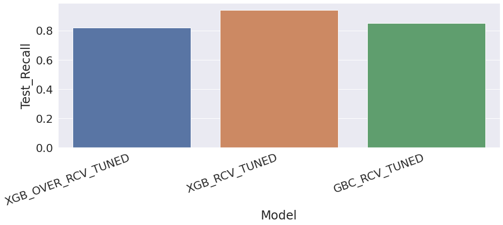

```python
fig, ax = plt.subplots()
fig.set_size_inches(15.7, 5.27)
ax = sns.barplot(y=model_score_table['Test_Recall'], x=model_score_table['Model'])
ax.set_xticklabels(ax.get_xticklabels(), rotation=20, ha="right")
```

# Model Performances - Choosing the best model

- From the plot above, we should go with **XGB_RCV_TUNED**.
- It gave a recall score of 93.8% on the validation data.
- Also gives desirable performance for recall score on the test data as well
- Also it had a score of 81.7 % F1 score on the validation data.

# Productionize the model

```python
# Make the pipeline with the tuned parameters of "XGB_RC_TUNED"
model = Pipeline(
    steps=[
        (
            "XGB_RC_TUNED",
            XGBClassifier(
                random_state=1,
               **new_params_xgb,
            ),
        ),
    ]
)
# Fit it on the training data.
model.fit(X_train, y_train)

# Performance on validation data
print("\nProductionized model performance on the validation data")
print_model_performance_for_classification(model=model,
                                           features=X_val,
                                           target=y_val)


print("\nProductionized model performance on the testing data")
print_model_performance_for_classification(model=model,
                                           features=X_test,
                                           target=y_test)
```

```
[23:53:27] WARNING: ../src/learner.cc:1115: Starting in XGBoost 1.3.0, the default evaluation metric used with the objective 'binary:logistic' was changed from 'error' to 'logloss'. Explicitly set eval_metric if you'd like to restore the old behavior.

Productionized model performance on the validation data
Accuracy:0.9323790720631787
Recall:0.9386503067484663
Precision: 0.723404255319149
F1 score: 0.8170894526034713

Productionized model performance on the testing data
Accuracy:0.9353405725567621
Recall:0.9353846153846154
Precision: 0.7342995169082126
F1 score: 0.8227334235453316
```

# Actionable Insights & Recommendations

## Use the XGB_RC_TUNED model

- Please use **XGB_RC_TUNED** to predict if a customer will attrite or not.
- Only take necessary reactions if you get >50% score.
- In the mean time, I will continue on improving the model.

## What can be done to avoid attrition of a customer?

- Often attrited customers have less utilization. To encourage them to use more, send promotion emails of our cashback deals etc to them.
- Also attrited customers have more contact with the bank. So when they reach out, inform them about the new benefits in using the card.
- Increase the credit limit (lets start with 5% for now). The more spending power they have, the more interested they are to use the card.
- If there is a customer with just 1 month of inactive status, please reach out to them immediately with our benefits or offers. Because if left as is, they will probably attrite after a month.
- On a monthly basis, send promotion emails of our other products. The more products they have, less likely they are to leave.